# Exercise: Adding Text to Plots

Math 493

### Getting the Data

We’re going to explore statistics for soccer teams in the top 5 European leagues: Bundesliga (GER), La Liga (ESP), Serie A (ITA), Premier League (ENG), and Ligue 1 (FRA). To get started, make sure you have the following packages installed and ready to go:

```r
library(tidyverse)
library(worldfootballR)
library(ggrepel)
```

The `worldfootballR` package allows us to get data from several popular soccer statistics sites, including FBRef, which is the one we will be using today. The following command downloads the standard team statistics like goals and assists for the current season ending in 2024. Take a look at the data in the viewer to get comfortable with what is there. Notice that it gives you stats for a given team, as well as the aggregated stats for all opponents that team has faced.

```r
#----- Get data for big five leagues for TEAMS -----#
big5_team_stats_full <- fb_big5_advanced_season_stats(
  season_end_year= c(2024),
  stat_type= "standard",
  team_or_player= "team"
  )
```

## Recreate this plot

Our goal in this section is to recreate the following plot:

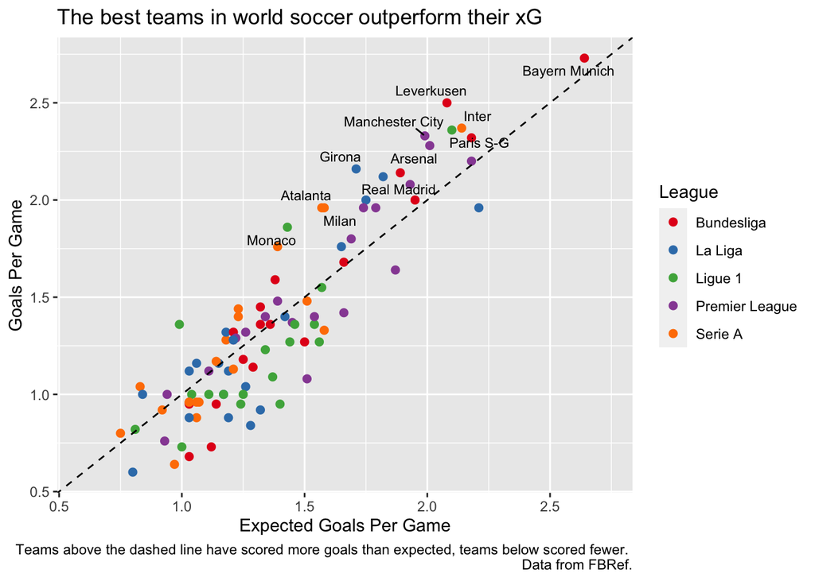

Here’s some steps to get your started. I recommend working through this in steps, adding new layers after you get the previous ones done.

- The plot only contains information of the number of goals scored, so you should first filter the `Team_or_Opponent` column.
- Next, make a basic scatter plot. The variables used are `Gls_Per` and `xG_Per`, which give the number of goals and expected goals per game. Color the points by the league.
- Add a line to the plot using `geom_abline`. Use the help reference to figure out how to make it a dashed line.
- The colors are from `Set1` in RColorBrewer
- Set the `x` and `y` limits to be the same.
- Label the plot.

Now let’s think about the labels. For this, we’re going to use a package called `ggrepel`, which has a function called `geom_text_repel`. This works in a similar way to the `geom_text` we learned last week, except that it moves the labels to be not on top of each other.

- create a new data set that has one row for each of the top 2 teams for `Gls_Per` from each league. Hint: use `group_by` and `slice_max`
- add a new `geom_text_repel` layer to the plot. Set `data=` to your new data set, and map the name of the top teams to the `label` aesthetic.
- Set the font size with `size=`.

And that’s it! Now you can use `ggrepel`.